# Investigation Overview

### In this investigation, I wanted to look at the flights information in the US from the years 2000 to 2008 and in the year 2003 in particular. The information I am intersted in are the relation between origin, destination, carriers and delays.

# Dataset Overview

### The U.S. Department of Transportation's Bureau of Transportation Statistics tracks the performance of domestic flights operated by large air carriers. This dataset has the information on the number of on-time, delayed, canceled and diverted flights.

## What are the ratios of the reasons of the cancelled flights in year 2003

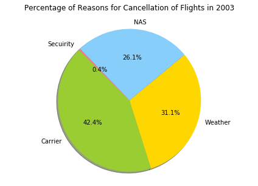

Carriers are the largest reason for cancellation

## What is the frequency of cancelled and diverted flights in each year from 2000 to 2008

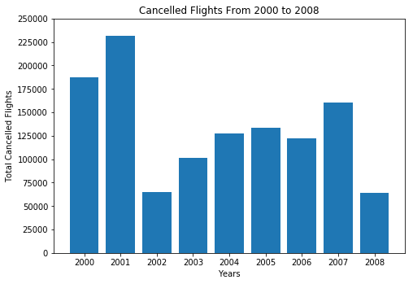

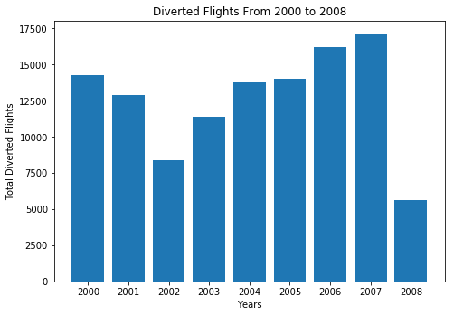

From the Bar chart above we see that the year 2007 has the most diverted flights but not with a large margin while the year 2008 has the lowest by a big margin

## What are the top 20 destination airports that divert flights in year 2003

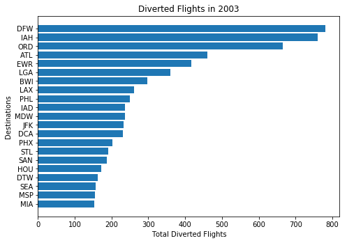

from the figure we know that DFW, IAH, and ORD has the most diverted flights in year 2003 by a big margin

## What is the relation between month of the year and the weather delay in year 2003

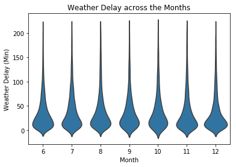

To have a good view pf the delays we removed the outliers and we noticed that most delays are below 50 minutes, and that the months from 1 to 5 did not have any weather delays

## What is the relation between distance and the arrival delay in year 2003

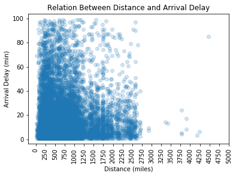

From the scatter plot we will notice that there is an inverse relation between the distance and the Arrival Delay so shorter trips tend to be more delayed than the longer ones

## What is the relation between departure delay and origin

### We will only work with the top 5 busiest airports

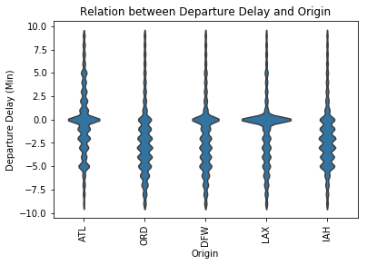

We notice that LAX airport is the airport with most departures on time and ORD and IAH are the most airports with early delays

## What is the average departure delay by origin from 2000 to 2008

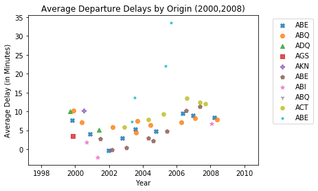

We will notice that most delays are between 0 and 10 minutes and also ABE airport has the largest delays

## What is the average arrival delay by destination from 2000 to 2008

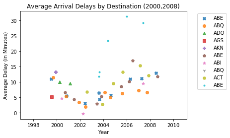

We will notice that most delays are between 0 and 15 minutes and also ABE airport has the largest delays

## What is the relation between arrival and departure delays with respect to carriers

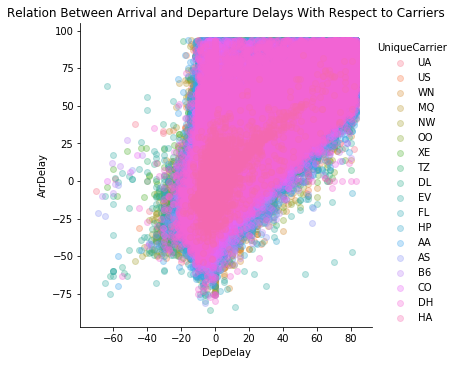

We can see that most delays are in the first quadrant so most arrival and departure delays tends to be from zero to 100, also there seems to be a large number of flights that depart and arrive early